# SARIMA in FABLE

2025-08-12

## Seasonal ARIMA models

| ARIMA | $~\underbrace{(p, d, q)}$ | $\underbrace{(P, D, Q)_{s}}$ |
| --- | --- | --- |
|  | ${\uparrow}$ | ${\uparrow}$ |
|  | Non-seasonal part | Seasonal part of |
|  | of the model | of the model |

where $s =$ number of observations per year.

## Seasonal ARIMA models

The seasonal part of an AR or MA model will be seen in the seasonal lags of the PACF and ACF.

## US leisure employment

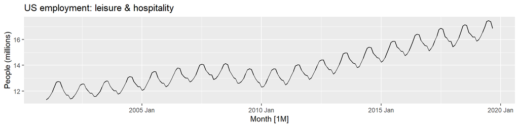

```r
leisure <- us_employment |>
  filter(Title == "Leisure and Hospitality", year(Month) > 2000) |>
  mutate(Employed = Employed / 1000) |>
  select(Month, Employed)
autoplot(leisure, Employed) +
  labs(title = "US employment: leisure & hospitality", y = "People (millions)")
```

We see strong seasonal effects that appear to be roughly constant and a trend. We thus first try to take seasonal differences (D=1):

## US leisure employment

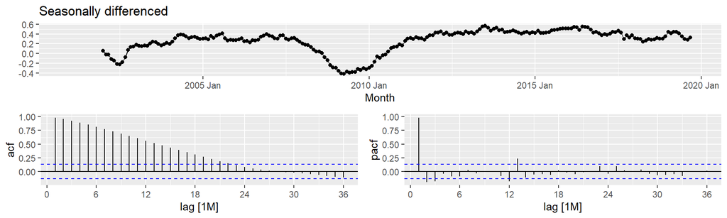

```r
leisure |>
  gg_tsdisplay(difference(Employed, 12), plot_type = "partial", lag = 36) +
  labs(title = "Seasonally differenced", y = "")
```

The resulting series still appears to be nonstationary, with slowly decreasing acf. We thus consider a further (non-seasonal) differencing (d=1):

## US leisure employment

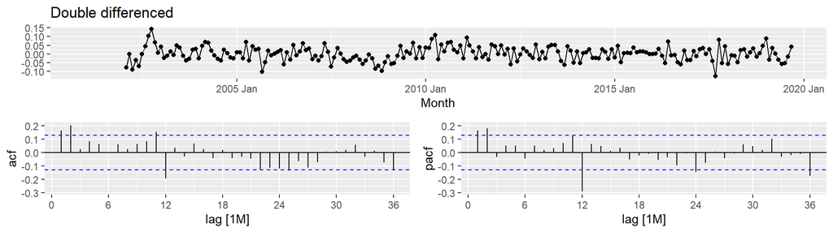

```r
leisure |>
  gg_tsdisplay(difference(Employed, 12) |> difference(),
    plot_type = "partial", lag = 36) +
  labs(title = "Double differenced", y = "")
```

We spot significant non seasonal lags for both the acf and pacf, indicating that a non-seasonal AR(2) or a non-seasonal MA(2) might be appropriate. Moreover, the significant pacf at lag 12 may indicate the need for a seasonal MA(1). We try the two different model specifications as well as the automatic choice of the ARIMA function:

## US leisure employment

```r
fit <- leisure |>
  model(arima012011 = ARIMA(Employed ~ pdq(0, 1, 2) + PDQ(0, 1, 1)),
        arima210011 = ARIMA(Employed ~ pdq(2, 1, 0) + PDQ(0, 1, 1)),
        auto = ARIMA(Employed, stepwise = FALSE, approx = FALSE))
fit |>
  pivot_longer(everything(),
    names_to = "Model name",
    values_to = "Orders")
```

```
## # A mable: 3 x 2
## # Key:     Model name [3]
##   `Model name`                    Orders
##   <chr>                          <model>
## 1 arima012011  <ARIMA(0,1,2)(0,1,1)[12]>
## 2 arima210011  <ARIMA(2,1,0)(0,1,1)[12]>
## 3 auto         <ARIMA(2,1,0)(1,1,1)[12]>
```

Let us consider the AICc/BIC values of the models:

## US leisure employment

```r
glance(fit) |>
  arrange(AICc) |>
  select(.model:BIC)
```

```
## # A tibble: 3 × 6
##   .model       sigma2 log_lik   AIC  AICc   BIC
##   <chr>         <dbl>   <dbl> <dbl> <dbl> <dbl>
## 1 auto        0.00142    395. -780. -780. -763.
## 2 arima210011 0.00145    392. -776. -776. -763.
## 3 arima012011 0.00146    391. -775. -775. -761.
```

## US leisure employment

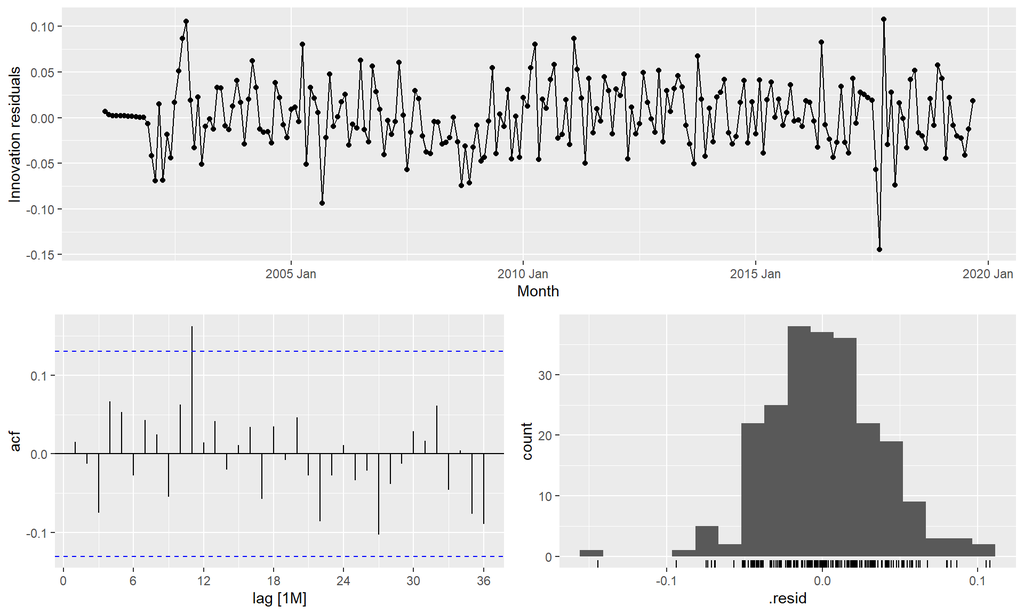

```r
fit |>
  select(auto) |>
  gg_tsresiduals(lag = 36)
```

Despite one significant lag in the acf (which can happen due to randomness), the assumption of the residuals being white noise appears reasonable. To test this further, we consider the distance autocorrelation function:

## US leisure employment

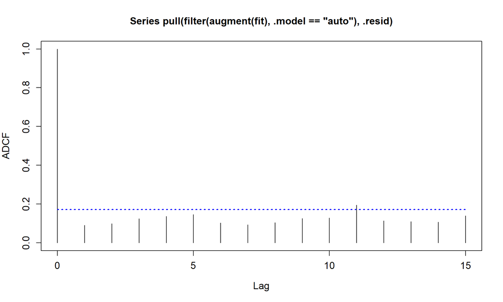

```
## $ADCF
##    lag 0      lag 1      lag 2     lag 3     lag 4     lag 5     lag 6
##        1 0.09087263 0.09934855 0.1248895 0.1363023 0.1462747 0.1032291
##         lag 7     lag 8     lag 9    lag 10    lag 11    lag 12    lag 13
##    0.09361841 0.1040048 0.1260781 0.1286135 0.1952636 0.1135907 0.1093088
##      lag 14    lag 15
##    0.107356 0.1395649
##
## $bootMethod
## [1] "Wild Bootstrap"
##
## $critical.values
## [1] 0.1713216
```

```r
#augment(fit) |>
#  filter(.model == "auto") |>
#  features(.innov, ljung_box, lag = 24, dof = 4)


augment(fit) |>
  filter(.model == "auto") |>
  pull(.resid) |>
  ADCFplot()
```

We note that the distance autocorrelation rejects $H_0$ of independence between residuals, indicating that further modelling might be possible. On the other hand, it is not clear how the siginificant value at lag 11 should or could be addressed. Thus we will choose this model for our analysis.

## US leisure employment

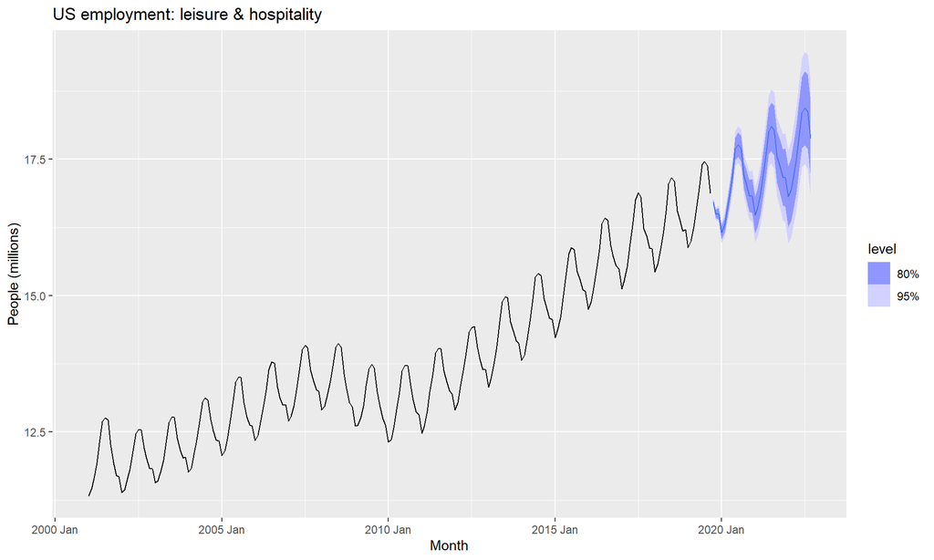

```r
forecast(fit, h = 36) |>
  filter(.model == "auto") |>
  autoplot(leisure) +
  labs(title = "US employment: leisure & hospitality", y = "People (millions)")
```